# Berries

Haoyu Wang

10/16/2020

# Introduction

As discussed in class, we’re going to wrap up Unit 1 by doing the “berries” dataset. What we need is to combine data cleaning, data organization, and EDA. Also, we need to visualize the data.

These data were collected from the USDA database selector: https://quickstats.nass.usda.gov

The data were [stored online](https://quickstats.nass.usda.gov/results/D416E96E-3D5C-324C-9334-1D38DF88FFF1) and then downloaded as a CSV file.

# Load and select meaningful data

After loading the data, we can see there are 21 columns who have no data or only single vale in some columns. Here are the columns names of unique value so that we can eliminate:

```
##  [1] "Program"          "Week Ending"      "Geo Level"        "Ag District"
##  [5] "Ag District Code" "County"           "County ANSI"      "Zip Code"
##  [9] "Region"           "watershed_code"   "Watershed"        "CV (%)"
```

Then we can eliminate the single value columns. The berries data had only 8 out of 21 columns containing meaningful data.

Year

Period

State

Commodity

Data Item

Domain

Domain Category

Value

2019

MARKETING YEAR

CALIFORNIA

BLUEBERRIES

BLUEBERRIES, TAME - PRICE RECEIVED, MEASURED IN $ / LB

TOTAL

NOT SPECIFIED

2.85

2019

MARKETING YEAR

CALIFORNIA

BLUEBERRIES

BLUEBERRIES, TAME, FRESH MARKET - PRICE RECEIVED, MEASURED IN $ / LB

TOTAL

NOT SPECIFIED

3.56

2019

MARKETING YEAR

CALIFORNIA

BLUEBERRIES

BLUEBERRIES, TAME, PROCESSING - PRICE RECEIVED, MEASURED IN $ / LB

TOTAL

NOT SPECIFIED

0.29

2019

MARKETING YEAR

CALIFORNIA

RASPBERRIES

RASPBERRIES - PRICE RECEIVED, MEASURED IN $ / LB

TOTAL

NOT SPECIFIED

2.69

2019

MARKETING YEAR

CALIFORNIA

RASPBERRIES

RASPBERRIES, FRESH MARKET - PRICE RECEIVED, MEASURED IN $ / LB

TOTAL

NOT SPECIFIED

2019

MARKETING YEAR

CALIFORNIA

RASPBERRIES

RASPBERRIES, PROCESSING - PRICE RECEIVED, MEASURED IN $ / LB

TOTAL

NOT SPECIFIED

2019

MARKETING YEAR

CALIFORNIA

STRAWBERRIES

STRAWBERRIES - PRICE RECEIVED, MEASURED IN $ / CWT

TOTAL

NOT SPECIFIED

108

2019

MARKETING YEAR

CALIFORNIA

STRAWBERRIES

STRAWBERRIES, FRESH MARKET - PRICE RECEIVED, MEASURED IN $ / CWT

TOTAL

NOT SPECIFIED

2019

MARKETING YEAR

CALIFORNIA

STRAWBERRIES

STRAWBERRIES, PROCESSING - PRICE RECEIVED, MEASURED IN $ / CWT

TOTAL

NOT SPECIFIED

2019

MARKETING YEAR

FLORIDA

BLUEBERRIES

BLUEBERRIES, TAME - PRICE RECEIVED, MEASURED IN $ / LB

TOTAL

NOT SPECIFIED

2.64

# Strawberries Since we need to clean and organize the dataset, we need to know how many kinds of berries we need to seperate.

```
## [1] "BLUEBERRIES"  "RASPBERRIES"  "STRAWBERRIES"
```

As we can see, there are three types of berries in this data set: blueberries, raspberries, and strawberries. Here I will choose strawberries.

| Year | State | Data Item | Domain | Domain Category | Value |
| --- | --- | --- | --- | --- | --- |
| 2019 | CALIFORNIA | STRAWBERRIES - ACRES HARVESTED | TOTAL | NOT SPECIFIED | 35,400 |
| 2019 | CALIFORNIA | STRAWBERRIES - ACRES PLANTED | TOTAL | NOT SPECIFIED | 36,000 |
| 2019 | CALIFORNIA | STRAWBERRIES - PRODUCTION, MEASURED IN $ | TOTAL | NOT SPECIFIED | 2,221,320,000 |
| 2019 | CALIFORNIA | STRAWBERRIES - PRODUCTION, MEASURED IN CWT | TOTAL | NOT SPECIFIED | 20,500,000 |
| 2019 | CALIFORNIA | STRAWBERRIES - YIELD, MEASURED IN CWT / ACRE | TOTAL | NOT SPECIFIED | 580 |
| 2019 | CALIFORNIA | STRAWBERRIES, BEARING - APPLICATIONS, MEASURED IN LB | CHEMICAL, FUNGICIDE | CHEMICAL, FUNGICIDE: (AZOXYSTROBIN = 128810) | 5,500 |
| 2019 | CALIFORNIA | STRAWBERRIES, BEARING - APPLICATIONS, MEASURED IN LB | CHEMICAL, FUNGICIDE | CHEMICAL, FUNGICIDE: (BACILLUS AMYLOLIQUEFACIENS MBI 600 = 129082) | (NA) |
| 2019 | CALIFORNIA | STRAWBERRIES, BEARING - APPLICATIONS, MEASURED IN LB | CHEMICAL, FUNGICIDE | CHEMICAL, FUNGICIDE: (BACILLUS AMYLOLIQUEFACIENS STRAIN D747 = 16482) | (NA) |
| 2019 | CALIFORNIA | STRAWBERRIES, BEARING - APPLICATIONS, MEASURED IN LB | CHEMICAL, FUNGICIDE | CHEMICAL, FUNGICIDE: (BACILLUS PUMILUS = 6485) | (NA) |
| 2019 | CALIFORNIA | STRAWBERRIES, BEARING - APPLICATIONS, MEASURED IN LB | CHEMICAL, FUNGICIDE | CHEMICAL, FUNGICIDE: (BACILLUS SUBT. GB03 = 129068) | (NA) |

## Clean and organize data

### Separate colums

From the table above, each row of ‘Data Item’ column has different information. In order to make the table look more organized, we need separate this column.Next, repeat eliminating unique column and doing NA replacment by using blank.

| Year | State | lab1 | lab2 | lab3 | lab4 | Domain | Domain Category | Value |
| --- | --- | --- | --- | --- | --- | --- | --- | --- |
| 2019 | CALIFORNIA | ACRES HARVESTED |  |  |  | TOTAL | NOT SPECIFIED | 35,400 |
| 2019 | CALIFORNIA | ACRES PLANTED |  |  |  | TOTAL | NOT SPECIFIED | 36,000 |
| 2019 | CALIFORNIA | PRODUCTION | MEASURED IN $ |  |  | TOTAL | NOT SPECIFIED | 2,221,320,000 |
| 2019 | CALIFORNIA | PRODUCTION | MEASURED IN CWT |  |  | TOTAL | NOT SPECIFIED | 20,500,000 |
| 2019 | CALIFORNIA | YIELD | MEASURED IN CWT / ACRE |  |  | TOTAL | NOT SPECIFIED | 580 |
| 2019 | CALIFORNIA |  | BEARING - APPLICATIONS | MEASURED IN LB |  | CHEMICAL, FUNGICIDE | CHEMICAL, FUNGICIDE: (AZOXYSTROBIN = 128810) | 5,500 |
| 2019 | CALIFORNIA |  | BEARING - APPLICATIONS | MEASURED IN LB |  | CHEMICAL, FUNGICIDE | CHEMICAL, FUNGICIDE: (BACILLUS AMYLOLIQUEFACIENS MBI 600 = 129082) | (NA) |
| 2019 | CALIFORNIA |  | BEARING - APPLICATIONS | MEASURED IN LB |  | CHEMICAL, FUNGICIDE | CHEMICAL, FUNGICIDE: (BACILLUS AMYLOLIQUEFACIENS STRAIN D747 = 16482) | (NA) |
| 2019 | CALIFORNIA |  | BEARING - APPLICATIONS | MEASURED IN LB |  | CHEMICAL, FUNGICIDE | CHEMICAL, FUNGICIDE: (BACILLUS PUMILUS = 6485) | (NA) |
| 2019 | CALIFORNIA |  | BEARING - APPLICATIONS | MEASURED IN LB |  | CHEMICAL, FUNGICIDE | CHEMICAL, FUNGICIDE: (BACILLUS SUBT. GB03 = 129068) | (NA) |

### Organize data

1. Check each column.

```
## [1] " ACRES HARVESTED" " ACRES PLANTED"   " PRODUCTION"      " YIELD"
## [5] " "
```

```
##  [1] " "                          " MEASURED IN $"
##  [3] " MEASURED IN CWT"           " MEASURED IN CWT / ACRE"
##  [5] " BEARING - APPLICATIONS"    " BEARING - TREATED"
##  [7] " FRESH MARKET - PRODUCTION" " FRESH MARKET"
##  [9] " NOT SOLD - PRODUCTION"     " PROCESSING - PRODUCTION"
## [11] " PROCESSING"                " UTILIZED - PRODUCTION"
```

```
## [1] " "
## [2] " MEASURED IN LB"
## [3] " MEASURED IN LB / ACRE / APPLICATION"
## [4] " MEASURED IN LB / ACRE / YEAR"
## [5] " MEASURED IN NUMBER"
## [6] " MEASURED IN PCT OF AREA BEARING"
## [7] " MEASURED IN $"
## [8] " UTILIZED - PRODUCTION"
## [9] " MEASURED IN CWT"
```

```
## [1] " "                 " AVG"              " MEASURED IN CWT"
## [4] " MEASURED IN TONS"
```

2. Note that we have entries in both the “lab2” and “lab3” columns that begin with “MEASURED”, and we also have entries in both the “lab3” and “lab4” columns that begin with “MEASURED”. We need to put them together in the same column, i.e., all the enreies that begin with “MEASURED” should be in “lab3” column. We have the new table below:

   | Year | State | lab1 | lab2 | lab3 | lab4 | Domain | Domain Category | Value |
   | --- | --- | --- | --- | --- | --- | --- | --- | --- |
   | 2019 | CALIFORNIA | ACRES HARVESTED |  |  |  | TOTAL | NOT SPECIFIED | 35,400 |
   | 2019 | CALIFORNIA | ACRES PLANTED |  |  |  | TOTAL | NOT SPECIFIED | 36,000 |
   | 2019 | CALIFORNIA | PRODUCTION |  | MEASURED IN $ |  | TOTAL | NOT SPECIFIED | 2,221,320,000 |
   | 2019 | CALIFORNIA | PRODUCTION |  | MEASURED IN CWT |  | TOTAL | NOT SPECIFIED | 20,500,000 |
   | 2019 | CALIFORNIA | YIELD |  | MEASURED IN CWT / ACRE |  | TOTAL | NOT SPECIFIED | 580 |
   | 2019 | CALIFORNIA |  | BEARING - APPLICATIONS | MEASURED IN LB |  | CHEMICAL, FUNGICIDE | CHEMICAL, FUNGICIDE: (AZOXYSTROBIN = 128810) | 5,500 |
   | 2019 | CALIFORNIA |  | BEARING - APPLICATIONS | MEASURED IN LB |  | CHEMICAL, FUNGICIDE | CHEMICAL, FUNGICIDE: (BACILLUS AMYLOLIQUEFACIENS MBI 600 = 129082) | (NA) |
   | 2019 | CALIFORNIA |  | BEARING - APPLICATIONS | MEASURED IN LB |  | CHEMICAL, FUNGICIDE | CHEMICAL, FUNGICIDE: (BACILLUS AMYLOLIQUEFACIENS STRAIN D747 = 16482) | (NA) |
   | 2019 | CALIFORNIA |  | BEARING - APPLICATIONS | MEASURED IN LB |  | CHEMICAL, FUNGICIDE | CHEMICAL, FUNGICIDE: (BACILLUS PUMILUS = 6485) | (NA) |
   | 2019 | CALIFORNIA |  | BEARING - APPLICATIONS | MEASURED IN LB |  | CHEMICAL, FUNGICIDE | CHEMICAL, FUNGICIDE: (BACILLUS SUBT. GB03 = 129068) | (NA) |

3. Check column “lab2”, “lab3” and “lab4” to make sure we did it right. There is no “UTILIZED - PRODUCTION” in “lab3” and all mesurments are in “lab3”.

```
## [1] ""                                    "BEARING - APPLICATIONS"
## [3] "BEARING - TREATED"                   "FRESH MARKET - PRODUCTION"
## [5] "FRESH MARKET  UTILIZED - PRODUCTION" "NOT SOLD - PRODUCTION"
## [7] "PROCESSING - PRODUCTION"             "PROCESSING  UTILIZED - PRODUCTION"
## [9] "UTILIZED - PRODUCTION"
```

```
##  [1] ""                                    "MEASURED IN $"
##  [3] "MEASURED IN CWT"                     "MEASURED IN CWT / ACRE"
##  [5] "MEASURED IN LB"                      "MEASURED IN LB / ACRE / APPLICATION"
##  [7] "MEASURED IN LB / ACRE / YEAR"        "MEASURED IN NUMBER"
##  [9] "MEASURED IN PCT OF AREA BEARING"     "MEASURED IN TONS"
```

```
## [1] " "    " AVG"
```

Next, let’s move to colum “Domain” and “Domian Category”. First, do the separation with those two columns. Next, remove redundant columns.

Then clean it up and rename the columns.

| Year | State | Production | Measurement | Avg | Materials | Chemical | Value |
| --- | --- | --- | --- | --- | --- | --- | --- |
| 2019 | CALIFORNIA | ACRES HARVESTED |  |  |  |  | 35,400 |
| 2019 | CALIFORNIA | ACRES PLANTED |  |  |  |  | 36,000 |
| 2019 | CALIFORNIA | PRODUCTION | MEASURED IN $ |  |  |  | 2,221,320,000 |
| 2019 | CALIFORNIA | PRODUCTION | MEASURED IN CWT |  |  |  | 20,500,000 |
| 2019 | CALIFORNIA | YIELD | MEASURED IN CWT / ACRE |  |  |  | 580 |
| 2019 | CALIFORNIA | BEARING - APPLICATIONS | MEASURED IN LB |  | (AZOXYSTROBIN = 128810) | FUNGICIDE | 5,500 |
| 2019 | CALIFORNIA | BEARING - APPLICATIONS | MEASURED IN LB |  | (BACILLUS AMYLOLIQUEFACIENS MBI 600 = 129082) | FUNGICIDE | (NA) |
| 2019 | CALIFORNIA | BEARING - APPLICATIONS | MEASURED IN LB |  | (BACILLUS AMYLOLIQUEFACIENS STRAIN D747 = 16482) | FUNGICIDE | (NA) |
| 2019 | CALIFORNIA | BEARING - APPLICATIONS | MEASURED IN LB |  | (BACILLUS PUMILUS = 6485) | FUNGICIDE | (NA) |
| 2019 | CALIFORNIA | BEARING - APPLICATIONS | MEASURED IN LB |  | (BACILLUS SUBT. GB03 = 129068) | FUNGICIDE | (NA) |

# EDA(Exploratory Data Analysis)

Let’s look at chemicals being applied to food.

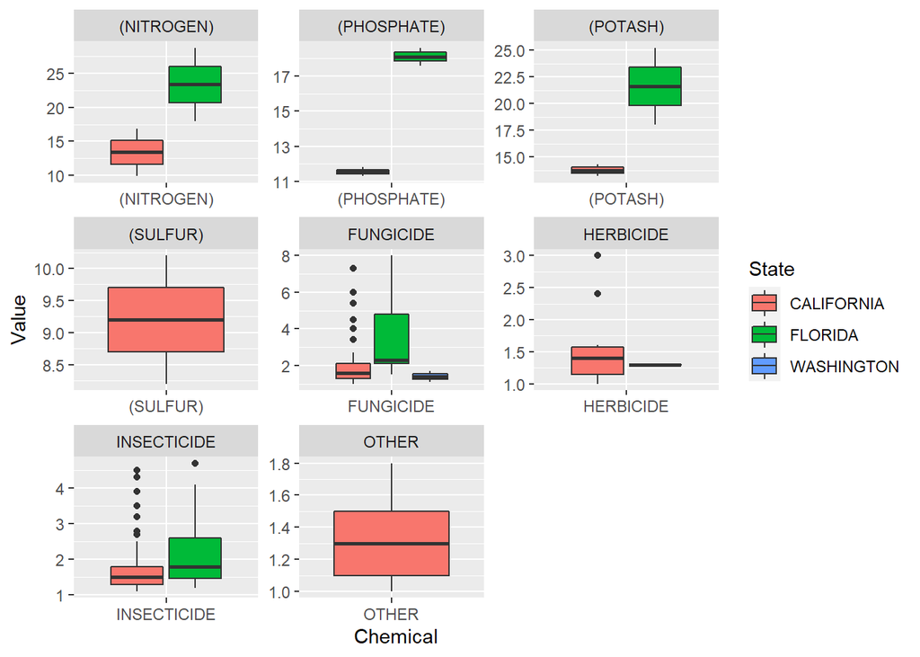

# Citations

Class recording 11, 14-18, MA615

http://rstudio.github.io/shiny/tutorial/

https://shiny.rstudio.com/tutorial/

Edwin de Jonge, Mark van der Loo, An introduction to data cleaning with R.

Garrett Grolemund, Hadley Wickham, R for Data Science, https://r4ds.had.co.nz/